# Risk Factor Analysis

## Outcome Variable

**Outcome Variable:** wasted

## Predictor Variables

**Intervention Variable:** hfoodsec

**Adjustment Set:**

unadjusted

## Stratifying Variables

The analysis was stratified on these variable(s):

- agecat
- studyid
- country

## Data Summary

| agecat | studyid | country | hfoodsec | wasted | n_cell | n |
| --- | --- | --- | --- | --- | --- | --- |
| Birth | GMS-Nepal | NEPAL | Food Secure | 0 | 347 | 620 |
| Birth | GMS-Nepal | NEPAL | Food Secure | 1 | 95 | 620 |
| Birth | GMS-Nepal | NEPAL | Mildly Food Insecure | 0 | 87 | 620 |
| Birth | GMS-Nepal | NEPAL | Mildly Food Insecure | 1 | 13 | 620 |
| Birth | GMS-Nepal | NEPAL | Food Insecure | 0 | 59 | 620 |
| Birth | GMS-Nepal | NEPAL | Food Insecure | 1 | 19 | 620 |
| Birth | JiVitA-3 | BANGLADESH | Food Secure | 0 | 5214 | 11763 |
| Birth | JiVitA-3 | BANGLADESH | Food Secure | 1 | 583 | 11763 |
| Birth | JiVitA-3 | BANGLADESH | Mildly Food Insecure | 0 | 3524 | 11763 |
| Birth | JiVitA-3 | BANGLADESH | Mildly Food Insecure | 1 | 423 | 11763 |
| Birth | JiVitA-3 | BANGLADESH | Food Insecure | 0 | 1787 | 11763 |
| Birth | JiVitA-3 | BANGLADESH | Food Insecure | 1 | 232 | 11763 |
| Birth | JiVitA-4 | BANGLADESH | Food Secure | 0 | 1093 | 2383 |
| Birth | JiVitA-4 | BANGLADESH | Food Secure | 1 | 112 | 2383 |
| Birth | JiVitA-4 | BANGLADESH | Mildly Food Insecure | 0 | 776 | 2383 |
| Birth | JiVitA-4 | BANGLADESH | Mildly Food Insecure | 1 | 94 | 2383 |
| Birth | JiVitA-4 | BANGLADESH | Food Insecure | 0 | 275 | 2383 |
| Birth | JiVitA-4 | BANGLADESH | Food Insecure | 1 | 33 | 2383 |
| Birth | MAL-ED | BANGLADESH | Food Secure | 0 | 113 | 162 |
| Birth | MAL-ED | BANGLADESH | Food Secure | 1 | 25 | 162 |
| Birth | MAL-ED | BANGLADESH | Mildly Food Insecure | 0 | 3 | 162 |
| Birth | MAL-ED | BANGLADESH | Mildly Food Insecure | 1 | 0 | 162 |
| Birth | MAL-ED | BANGLADESH | Food Insecure | 0 | 17 | 162 |
| Birth | MAL-ED | BANGLADESH | Food Insecure | 1 | 4 | 162 |
| Birth | MAL-ED | BRAZIL | Food Secure | 0 | 0 | 26 |
| Birth | MAL-ED | BRAZIL | Food Secure | 1 | 0 | 26 |
| Birth | MAL-ED | BRAZIL | Mildly Food Insecure | 0 | 4 | 26 |
| Birth | MAL-ED | BRAZIL | Mildly Food Insecure | 1 | 0 | 26 |
| Birth | MAL-ED | BRAZIL | Food Insecure | 0 | 21 | 26 |
| Birth | MAL-ED | BRAZIL | Food Insecure | 1 | 1 | 26 |

[output cut: 168 more lines]

The following strata were considered:

- agecat: 24 months, studyid: GMS-Nepal, country: NEPAL
- agecat: 24 months, studyid: JiVitA-3, country: BANGLADESH
- agecat: 24 months, studyid: JiVitA-4, country: BANGLADESH
- agecat: 24 months, studyid: MAL-ED, country: BANGLADESH
- agecat: 24 months, studyid: MAL-ED, country: BRAZIL
- agecat: 24 months, studyid: MAL-ED, country: INDIA
- agecat: 24 months, studyid: MAL-ED, country: NEPAL
- agecat: 24 months, studyid: MAL-ED, country: PERU
- agecat: 24 months, studyid: MAL-ED, country: SOUTH AFRICA
- agecat: 24 months, studyid: NIH-Birth, country: BANGLADESH
- agecat: 24 months, studyid: NIH-Crypto, country: BANGLADESH
- agecat: 6 months, studyid: GMS-Nepal, country: NEPAL
- agecat: 6 months, studyid: JiVitA-3, country: BANGLADESH
- agecat: 6 months, studyid: JiVitA-4, country: BANGLADESH
- agecat: 6 months, studyid: MAL-ED, country: BANGLADESH
- agecat: 6 months, studyid: MAL-ED, country: BRAZIL
- agecat: 6 months, studyid: MAL-ED, country: INDIA
- agecat: 6 months, studyid: MAL-ED, country: NEPAL
- agecat: 6 months, studyid: MAL-ED, country: PERU
- agecat: 6 months, studyid: MAL-ED, country: SOUTH AFRICA
- agecat: 6 months, studyid: NIH-Birth, country: BANGLADESH
- agecat: 6 months, studyid: NIH-Crypto, country: BANGLADESH
- agecat: Birth, studyid: GMS-Nepal, country: NEPAL
- agecat: Birth, studyid: JiVitA-3, country: BANGLADESH
- agecat: Birth, studyid: JiVitA-4, country: BANGLADESH
- agecat: Birth, studyid: MAL-ED, country: BANGLADESH
- agecat: Birth, studyid: MAL-ED, country: BRAZIL
- agecat: Birth, studyid: MAL-ED, country: INDIA
- agecat: Birth, studyid: MAL-ED, country: NEPAL
- agecat: Birth, studyid: MAL-ED, country: PERU
- agecat: Birth, studyid: MAL-ED, country: SOUTH AFRICA
- agecat: Birth, studyid: NIH-Birth, country: BANGLADESH
- agecat: Birth, studyid: NIH-Crypto, country: BANGLADESH

### Dropped Strata

Some strata were dropped due to rare outcomes:

- agecat: Birth, studyid: MAL-ED, country: BANGLADESH
- agecat: Birth, studyid: MAL-ED, country: BRAZIL
- agecat: Birth, studyid: MAL-ED, country: INDIA
- agecat: Birth, studyid: MAL-ED, country: NEPAL
- agecat: Birth, studyid: MAL-ED, country: PERU
- agecat: Birth, studyid: MAL-ED, country: SOUTH AFRICA
- agecat: 6 months, studyid: GMS-Nepal, country: NEPAL
- agecat: 6 months, studyid: MAL-ED, country: BANGLADESH
- agecat: 6 months, studyid: MAL-ED, country: BRAZIL
- agecat: 6 months, studyid: MAL-ED, country: INDIA
- agecat: 6 months, studyid: MAL-ED, country: NEPAL
- agecat: 6 months, studyid: MAL-ED, country: PERU
- agecat: 6 months, studyid: MAL-ED, country: SOUTH AFRICA
- agecat: 6 months, studyid: NIH-Birth, country: BANGLADESH
- agecat: 6 months, studyid: NIH-Crypto, country: BANGLADESH
- agecat: 24 months, studyid: MAL-ED, country: BANGLADESH
- agecat: 24 months, studyid: MAL-ED, country: BRAZIL
- agecat: 24 months, studyid: MAL-ED, country: INDIA
- agecat: 24 months, studyid: MAL-ED, country: NEPAL
- agecat: 24 months, studyid: MAL-ED, country: PERU
- agecat: 24 months, studyid: MAL-ED, country: SOUTH AFRICA
- agecat: 24 months, studyid: NIH-Birth, country: BANGLADESH

## Methods Detail

We’re interested in the causal parameters $E[Y_a]$ for all values of $a \in \mathcal{A}$. These parameters represent the mean outcome if, possibly contrary to fact, we intervened to set all units to have $A=a$. Under the randomization and positivity assumptions, these are identified by the statistical parameters $\psi_a=E_W[E_{Y|A,W}(Y|A=a,W)]$. In addition, we’re interested in the mean of $Y$, $E[Y]$ under no intervention (the observed mean). We will estimate these parameters by using SuperLearner to fit the relevant likelihood factors – $E_{Y|A,W}(Y|A=a,W)$ and $p(A=a|W)$, and then updating our likelihood fit using a joint TMLE.

For unadjusted analyses ($W=\{\}$), initial likelihoods were estimated using Lrnr_glm to estimate the simple $E(Y|A)$ and Lrnr_mean to estimate $p(A)$. For adjusted analyses, a small library containing Lrnr_glmnet, Lrnr_xgboost, and Lrnr_mean was used.

Having estimated these parameters, we will then use the delta method to estimate relative risks and attributable risks relative to a prespecified baseline level of $A$.

# Results Detail

## Results Plots

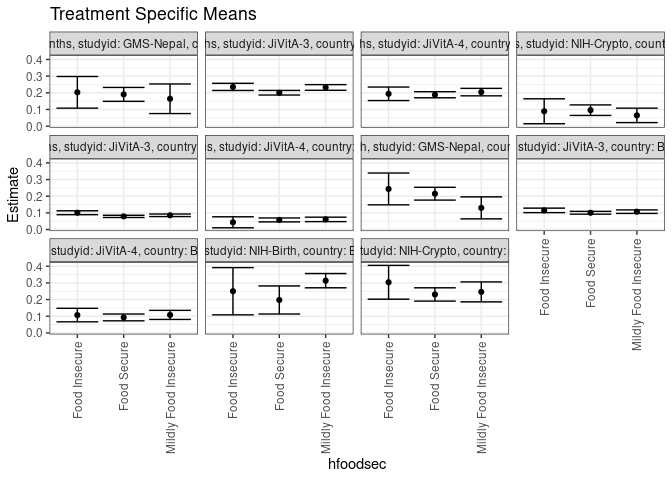

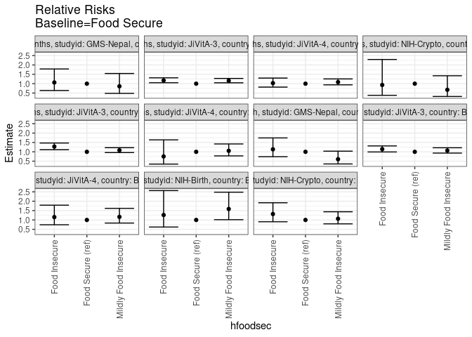

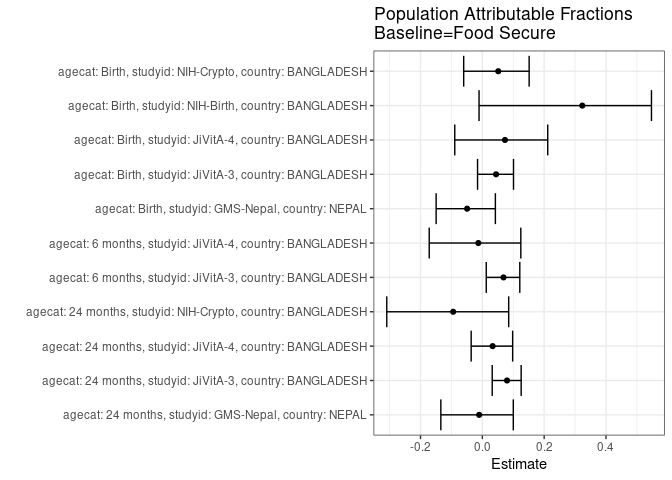

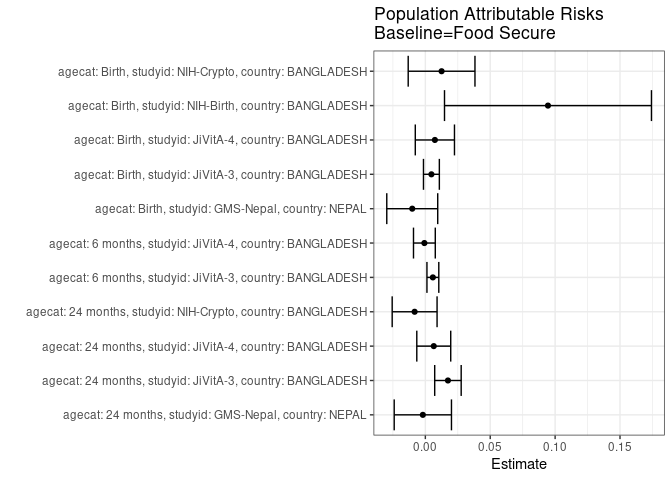

## Results Table

### Parameter: TSM

| agecat | studyid | country | intervention_level | baseline_level | estimate | ci_lower | ci_upper |
| --- | --- | --- | --- | --- | --- | --- | --- |
| Birth | GMS-Nepal | NEPAL | Food Secure | NA | 0.2149321 | 0.1766063 | 0.2532580 |
| Birth | GMS-Nepal | NEPAL | Mildly Food Insecure | NA | 0.1300000 | 0.0640325 | 0.1959675 |
| Birth | GMS-Nepal | NEPAL | Food Insecure | NA | 0.2435897 | 0.1482532 | 0.3389263 |
| Birth | JiVitA-3 | BANGLADESH | Food Secure | NA | 0.1005693 | 0.0921140 | 0.1090245 |
| Birth | JiVitA-3 | BANGLADESH | Mildly Food Insecure | NA | 0.1071700 | 0.0965185 | 0.1178215 |
| Birth | JiVitA-3 | BANGLADESH | Food Insecure | NA | 0.1149084 | 0.1014271 | 0.1283897 |
| Birth | JiVitA-4 | BANGLADESH | Food Secure | NA | 0.0929461 | 0.0725815 | 0.1133106 |
| Birth | JiVitA-4 | BANGLADESH | Mildly Food Insecure | NA | 0.1080460 | 0.0807836 | 0.1353083 |
| Birth | JiVitA-4 | BANGLADESH | Food Insecure | NA | 0.1071429 | 0.0665162 | 0.1477695 |
| Birth | NIH-Birth | BANGLADESH | Food Secure | NA | 0.1976744 | 0.1134327 | 0.2819162 |
| Birth | NIH-Birth | BANGLADESH | Mildly Food Insecure | NA | 0.3134658 | 0.2707092 | 0.3562224 |
| Birth | NIH-Birth | BANGLADESH | Food Insecure | NA | 0.2500000 | 0.1084286 | 0.3915714 |
| Birth | NIH-Crypto | BANGLADESH | Food Secure | NA | 0.2307692 | 0.1908719 | 0.2706666 |
| Birth | NIH-Crypto | BANGLADESH | Mildly Food Insecure | NA | 0.2462312 | 0.1863322 | 0.3061301 |
| Birth | NIH-Crypto | BANGLADESH | Food Insecure | NA | 0.3037975 | 0.2023125 | 0.4052824 |
| 6 months | JiVitA-3 | BANGLADESH | Food Secure | NA | 0.0788471 | 0.0721168 | 0.0855773 |
| 6 months | JiVitA-3 | BANGLADESH | Mildly Food Insecure | NA | 0.0853309 | 0.0777954 | 0.0928665 |
| 6 months | JiVitA-3 | BANGLADESH | Food Insecure | NA | 0.1007919 | 0.0892531 | 0.1123308 |
| 6 months | JiVitA-4 | BANGLADESH | Food Secure | NA | 0.0576687 | 0.0460356 | 0.0693018 |
| 6 months | JiVitA-4 | BANGLADESH | Mildly Food Insecure | NA | 0.0607639 | 0.0473306 | 0.0741972 |
| 6 months | JiVitA-4 | BANGLADESH | Food Insecure | NA | 0.0434084 | 0.0104539 | 0.0763628 |
| 24 months | GMS-Nepal | NEPAL | Food Secure | NA | 0.1906158 | 0.1488825 | 0.2323492 |
| 24 months | GMS-Nepal | NEPAL | Mildly Food Insecure | NA | 0.1641791 | 0.0753854 | 0.2529728 |
| 24 months | GMS-Nepal | NEPAL | Food Insecure | NA | 0.2028986 | 0.1079091 | 0.2978880 |
| 24 months | JiVitA-3 | BANGLADESH | Food Secure | NA | 0.2004148 | 0.1865436 | 0.2142860 |
| 24 months | JiVitA-3 | BANGLADESH | Mildly Food Insecure | NA | 0.2321104 | 0.2150817 | 0.2491391 |
| 24 months | JiVitA-3 | BANGLADESH | Food Insecure | NA | 0.2354430 | 0.2141082 | 0.2567779 |
| 24 months | JiVitA-4 | BANGLADESH | Food Secure | NA | 0.1883633 | 0.1700380 | 0.2066886 |
| 24 months | JiVitA-4 | BANGLADESH | Mildly Food Insecure | NA | 0.2042378 | 0.1819555 | 0.2265200 |
| 24 months | JiVitA-4 | BANGLADESH | Food Insecure | NA | 0.1940789 | 0.1534371 | 0.2347208 |
| 24 months | NIH-Crypto | BANGLADESH | Food Secure | NA | 0.0958084 | 0.0642126 | 0.1274042 |
| 24 months | NIH-Crypto | BANGLADESH | Mildly Food Insecure | NA | 0.0645161 | 0.0212336 | 0.1077986 |
| 24 months | NIH-Crypto | BANGLADESH | Food Insecure | NA | 0.0892857 | 0.0145275 | 0.1640439 |

### Parameter: E(Y)

| agecat | studyid | country | intervention_level | baseline_level | estimate | ci_lower | ci_upper |
| --- | --- | --- | --- | --- | --- | --- | --- |
| Birth | GMS-Nepal | NEPAL | NA | NA | 0.2048387 | 0.1730454 | 0.2366321 |
| Birth | JiVitA-3 | BANGLADESH | NA | NA | 0.1052453 | 0.0993428 | 0.1111477 |
| Birth | JiVitA-4 | BANGLADESH | NA | NA | 0.1002937 | 0.0848872 | 0.1157003 |
| Birth | NIH-Birth | BANGLADESH | NA | NA | 0.2921739 | 0.2549711 | 0.3293768 |
| Birth | NIH-Crypto | BANGLADESH | NA | NA | 0.2432815 | 0.2116319 | 0.2749310 |
| 6 months | JiVitA-3 | BANGLADESH | NA | NA | 0.0846457 | 0.0798459 | 0.0894454 |
| 6 months | JiVitA-4 | BANGLADESH | NA | NA | 0.0569343 | 0.0480657 | 0.0658029 |
| 24 months | GMS-Nepal | NEPAL | NA | NA | 0.1886792 | 0.1535311 | 0.2238274 |
| 24 months | JiVitA-3 | BANGLADESH | NA | NA | 0.2178266 | 0.2079286 | 0.2277246 |
| 24 months | JiVitA-4 | BANGLADESH | NA | NA | 0.1948467 | 0.1815077 | 0.2081857 |
| 24 months | NIH-Crypto | BANGLADESH | NA | NA | 0.0875486 | 0.0630907 | 0.1120065 |

### Parameter: RR

| agecat | studyid | country | intervention_level | baseline_level | estimate | ci_lower | ci_upper |
| --- | --- | --- | --- | --- | --- | --- | --- |
| Birth | GMS-Nepal | NEPAL | Food Secure | Food Secure | 1.0000000 | 1.0000000 | 1.000000 |
| Birth | GMS-Nepal | NEPAL | Mildly Food Insecure | Food Secure | 0.6048421 | 0.3532255 | 1.035695 |
| Birth | GMS-Nepal | NEPAL | Food Insecure | Food Secure | 1.1333333 | 0.7371783 | 1.742380 |
| Birth | JiVitA-3 | BANGLADESH | Food Secure | Food Secure | 1.0000000 | 1.0000000 | 1.000000 |
| Birth | JiVitA-3 | BANGLADESH | Mildly Food Insecure | Food Secure | 1.0656338 | 0.9322760 | 1.218068 |
| Birth | JiVitA-3 | BANGLADESH | Food Insecure | Food Secure | 1.1425795 | 0.9925018 | 1.315351 |
| Birth | JiVitA-4 | BANGLADESH | Food Secure | Food Secure | 1.0000000 | 1.0000000 | 1.000000 |
| Birth | JiVitA-4 | BANGLADESH | Mildly Food Insecure | Food Secure | 1.1624589 | 0.8345924 | 1.619127 |
| Birth | JiVitA-4 | BANGLADESH | Food Insecure | Food Secure | 1.1527423 | 0.7424337 | 1.789810 |
| Birth | NIH-Birth | BANGLADESH | Food Secure | Food Secure | 1.0000000 | 1.0000000 | 1.000000 |
| Birth | NIH-Birth | BANGLADESH | Mildly Food Insecure | Food Secure | 1.5857681 | 1.0137016 | 2.480671 |
| Birth | NIH-Birth | BANGLADESH | Food Insecure | Food Secure | 1.2647059 | 0.6225768 | 2.569130 |
| Birth | NIH-Crypto | BANGLADESH | Food Secure | Food Secure | 1.0000000 | 1.0000000 | 1.000000 |
| Birth | NIH-Crypto | BANGLADESH | Mildly Food Insecure | Food Secure | 1.0670017 | 0.7916870 | 1.438059 |
| Birth | NIH-Crypto | BANGLADESH | Food Insecure | Food Secure | 1.3164557 | 0.9037530 | 1.917621 |
| 6 months | JiVitA-3 | BANGLADESH | Food Secure | Food Secure | 1.0000000 | 1.0000000 | 1.000000 |
| 6 months | JiVitA-3 | BANGLADESH | Mildly Food Insecure | Food Secure | 1.0822336 | 0.9593723 | 1.220829 |
| 6 months | JiVitA-3 | BANGLADESH | Food Insecure | Food Secure | 1.2783219 | 1.1113581 | 1.470369 |
| 6 months | JiVitA-4 | BANGLADESH | Food Secure | Food Secure | 1.0000000 | 1.0000000 | 1.000000 |
| 6 months | JiVitA-4 | BANGLADESH | Mildly Food Insecure | Food Secure | 1.0536717 | 0.7823741 | 1.419045 |
| 6 months | JiVitA-4 | BANGLADESH | Food Insecure | Food Secure | 0.7527194 | 0.3460734 | 1.637186 |
| 24 months | GMS-Nepal | NEPAL | Food Secure | Food Secure | 1.0000000 | 1.0000000 | 1.000000 |
| 24 months | GMS-Nepal | NEPAL | Mildly Food Insecure | Food Secure | 0.8613088 | 0.4805754 | 1.543676 |
| 24 months | GMS-Nepal | NEPAL | Food Insecure | Food Secure | 1.0644370 | 0.6348405 | 1.784741 |
| 24 months | JiVitA-3 | BANGLADESH | Food Secure | Food Secure | 1.0000000 | 1.0000000 | 1.000000 |
| 24 months | JiVitA-3 | BANGLADESH | Mildly Food Insecure | Food Secure | 1.1581499 | 1.0471476 | 1.280919 |
| 24 months | JiVitA-3 | BANGLADESH | Food Insecure | Food Secure | 1.1747785 | 1.0509335 | 1.313218 |
| 24 months | JiVitA-4 | BANGLADESH | Food Secure | Food Secure | 1.0000000 | 1.0000000 | 1.000000 |
| 24 months | JiVitA-4 | BANGLADESH | Mildly Food Insecure | Food Secure | 1.0842757 | 0.9374459 | 1.254103 |
| 24 months | JiVitA-4 | BANGLADESH | Food Insecure | Food Secure | 1.0303436 | 0.8172833 | 1.298947 |
| 24 months | NIH-Crypto | BANGLADESH | Food Secure | Food Secure | 1.0000000 | 1.0000000 | 1.000000 |
| 24 months | NIH-Crypto | BANGLADESH | Mildly Food Insecure | Food Secure | 0.6733871 | 0.3188651 | 1.422075 |
| 24 months | NIH-Crypto | BANGLADESH | Food Insecure | Food Secure | 0.9319196 | 0.3789294 | 2.291916 |

### Parameter: PAR

| agecat | studyid | country | intervention_level | baseline_level | estimate | ci_lower | ci_upper |
| --- | --- | --- | --- | --- | --- | --- | --- |
| Birth | GMS-Nepal | NEPAL | Food Secure | NA | -0.0100934 | -0.0297241 | 0.0095372 |
| Birth | JiVitA-3 | BANGLADESH | Food Secure | NA | 0.0046760 | -0.0014392 | 0.0107912 |
| Birth | JiVitA-4 | BANGLADESH | Food Secure | NA | 0.0073477 | -0.0077489 | 0.0224443 |
| Birth | NIH-Birth | BANGLADESH | Food Secure | NA | 0.0944995 | 0.0147631 | 0.1742359 |
| Birth | NIH-Crypto | BANGLADESH | Food Secure | NA | 0.0125122 | -0.0132117 | 0.0382362 |
| 6 months | JiVitA-3 | BANGLADESH | Food Secure | NA | 0.0057986 | 0.0012328 | 0.0103644 |
| 6 months | JiVitA-4 | BANGLADESH | Food Secure | NA | -0.0007344 | -0.0091289 | 0.0076601 |
| 24 months | GMS-Nepal | NEPAL | Food Secure | NA | -0.0019366 | -0.0240019 | 0.0201287 |
| 24 months | JiVitA-3 | BANGLADESH | Food Secure | NA | 0.0174118 | 0.0072086 | 0.0276149 |
| 24 months | JiVitA-4 | BANGLADESH | Food Secure | NA | 0.0064833 | -0.0065888 | 0.0195555 |
| 24 months | NIH-Crypto | BANGLADESH | Food Secure | NA | -0.0082597 | -0.0255539 | 0.0090344 |

### Parameter: PAF

| agecat | studyid | country | intervention_level | baseline_level | estimate | ci_lower | ci_upper |
| --- | --- | --- | --- | --- | --- | --- | --- |
| Birth | GMS-Nepal | NEPAL | Food Secure | NA | -0.0492749 | -0.1494688 | 0.0421855 |
| Birth | JiVitA-3 | BANGLADESH | Food Secure | NA | 0.0444296 | -0.0155074 | 0.1008289 |
| Birth | JiVitA-4 | BANGLADESH | Food Secure | NA | 0.0732617 | -0.0892305 | 0.2115132 |
| Birth | NIH-Birth | BANGLADESH | Food Secure | NA | 0.3234358 | -0.0106683 | 0.5470926 |
| Birth | NIH-Crypto | BANGLADESH | Food Secure | NA | 0.0514311 | -0.0603323 | 0.1514142 |
| 6 months | JiVitA-3 | BANGLADESH | Food Secure | NA | 0.0685044 | 0.0126916 | 0.1211620 |
| 6 months | JiVitA-4 | BANGLADESH | Food Secure | NA | -0.0128992 | -0.1718428 | 0.1244860 |
| 24 months | GMS-Nepal | NEPAL | Food Secure | NA | -0.0102639 | -0.1342383 | 0.1001598 |
| 24 months | JiVitA-3 | BANGLADESH | Food Secure | NA | 0.0799342 | 0.0319153 | 0.1255712 |
| 24 months | JiVitA-4 | BANGLADESH | Food Secure | NA | 0.0332741 | -0.0361486 | 0.0980454 |
| 24 months | NIH-Crypto | BANGLADESH | Food Secure | NA | -0.0943446 | -0.3091652 | 0.0852260 |